# Covid Research Project

Ben Mehani

2025-04-16

## Introduction

The COVID-19 pandemic exposed many vulnerabilities in America’s prison system, especially regarding outbreak control and how they spread through certain correctional facilities. While some institutions reported only a few cases, others became major hotspots. This raises important questions about what factors contributed to the difference in these outcomes, particularly whether the type of facility played a role in the total number of reported inmate cases.

With this in mind, I investigate the question: Is there a relationship between the type of facility and the average number of inmate COVID-19 cases? I explore how various facility types, such as federal prisons, state prisons, and others, compare in terms of case counts and whether certain types are associated with higher case numbers.

I found strong evidence that the type of facility is associated with differences in the average number of inmate COVID-19 cases.

## Background

#### Data Sources

The data comes from the New York Times. It was collected from websites that were overseen by state/federal prison systems, and there was also data from Immigration and Customs Enforcement. Not publicly available data was retrieved through direct requests and inquiries by NYT. The information was collected from 2,805 facilities from March 2020 to March 2021.

- **Data Link:** https://github.com/nytimes/covid-19-data/blob/master/prisons/facilities.csv

#### Variables and Data Structure

In terms of variables, I used facility type, population, and inmate cases.

- **Facility type** is the type of jail/prison that specific location is. This could be state or federal prisons, immigration detention centers, juvenile detention facilities, or local jails.
- The **population** variable is the highest number of inmates that were at the specific facility from March 2020 to March 2021. For the population variable, we renamed it to total_pop and summed it up into one category for each type of facility.
- The **cases** variable is the number of positively-tested COVID cases during that time period and it is also totaled for each type of facility.
- The **infection rate** variable is the rate of COVID in each facility type. We calculated this column by dividing the inmate cases by the total population of each facility type (population).
- Each **row** of our cleaned dataset shows a type of facility and its total population, inmate population, inmate cases, and infection rate in that singular facility.
- The **sample size** is 12, which represents the total amount of facility types.

#### Background Information

The data focuses on the COVID-19 pandemic that started in the United States in March 2020. This was the peak of coronavirus where the U.S. went under lockdown for several months. Taking the data during this time means this demographic of people we are looking at in prisons/jails was particularly vulnerable to infection–far more than regular populations–because it was much harder to control in tightly packed and confined facilities. The question explores the rate of COVID-19 contraction among inmates. We are specifically looking to see if there are any patterns in the infection rate of inmates when it comes to COVID-19 in different types of prisons/jails.

There are some **unusual** and unique cases in the facilities data. Firstly, if an inmate or officer contracted Covid multiple times, it would only be listed as one case in the dataset. Another event would be if a positively-tested inmate is transferred to a different facility also in the dataset, then that case would only be listed in the original facility.

#### Data Processing and Visualization

The facilities dataset was cleaned by only selecting the columns we were interested in and filtering out facilities that had no data on the population. It was processed by grouping all the facilities into 12 groups based on the type of facility they were and their infection rates were calculated and added to the dataset.

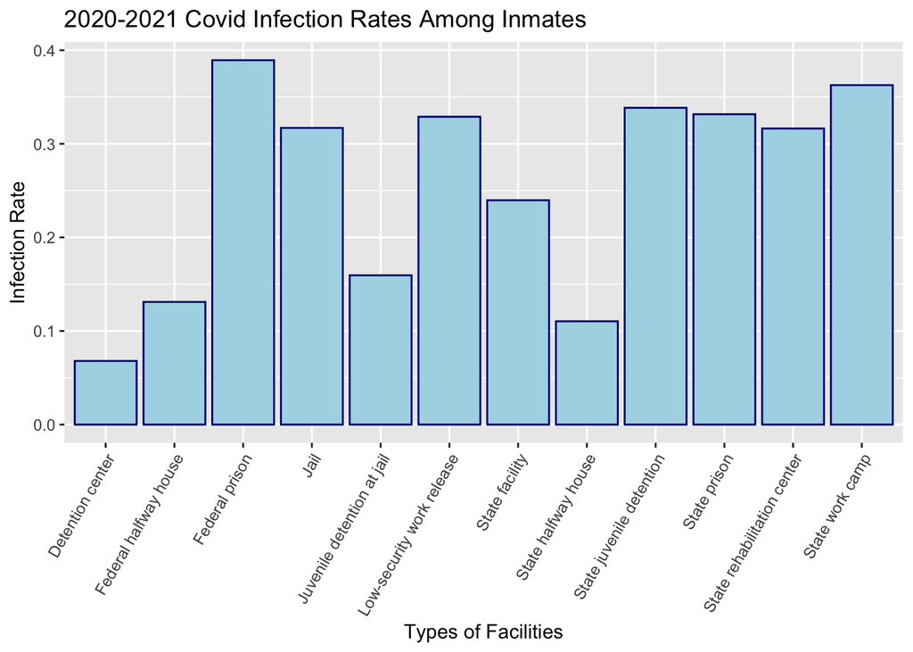

This graph is a bar graph of types of facilities and the infection rate of each. Each bar represents a type of facility and the height of the bar is the infection rate of that facility, which ranges from around 0 to 0.4 or 0% to 40%.

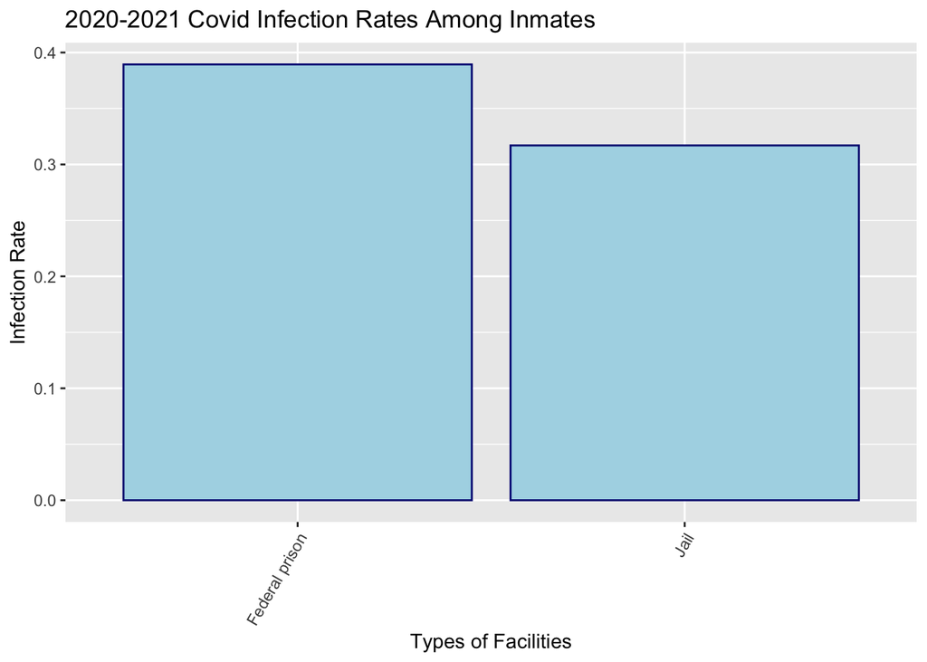

This graph is a more specific bar graph with just data about federal prison and jail, which are the two particular populations we are comparing.

## Statistical Analysis

This study investigates the difference in COVID-19 infection rates between federal prisons and jails. We will conduct a two-tailed hypothesis test because we have no prior reason to suspect a difference in the probability of getting infected in a jail vs in a federal prison.

#### Parameters of Interest

Our **parameters of interest** are the true probabilities of an inmate getting infected in jails vs in federal prisons.

- p1 = probability of an inmate being infected in a federal prison
- p2= probability of an inmate being infected in a jail

#### Type of Inference

We will be computing a difference of proportions.

#### Assumptions

- X1 = the observed proportion of infected federal prison inmates to total federal prison population ~ Binom(137905, p1), n1 = 137905
- X2 = the observed proportion of infected jail inmates to total jail population ~ Binom(146803, p2), n2 = 146803

**Independence**: It is assumed that the groups (jail population and federal prison population) are independent from each other. This assumption is satisfied as the data was collected from separate groups

**Normality**: It is assumed that the sample mean of each group is approximately normally distributed.

**BINS Assumptions**: It is assumed that BINS is all true.

#### Hypotheses

- H_0: p1 = p2, p1 - p2 = 0
- H_a: p1 $\neq$ p2, p1 - p2 $\neq$ 0

#### Test Statistic and Null Distribution

Test statistic is calculated as:

- Test statistic is calculated as: ((p1hat - p2hat) - 0) / sqrt((pbar(1-pbar)) / n1) + (pbar(1-pbar)) / n2) ~ N(0, 1) (null distribution)
- Where pbar = (X1 + X2)/(n1 + n2)

#### Results

- **Test Statistic**: 40.39949
- **P-val** = 0 (output rounded to 0 in R)

#### Interpretation

P-val < alpha = 0.05, so we reject the null hypothesis since we have evidence that the infection rate in federal prisons is higher than the infection rate in jails.

## Discussion

#### Further Interpretation

The results of this analysis show that the p-value (0) is less than the significance level of 0.05. This provides strong evidence that we reject the null hypothesis and conclude that there is a significant relationship between the type of facility and the average number of inmate COVID-19 cases when analyzing infection rates in federal prisons and jails.

The combination of the extremely small p-value and a very large test statistic provides strong evidence of a difference in COVID-19 infection rates between jails and federal prisons, with federal prisons showing significantly higher infection rates.

#### Shortcomings of the Analysis

**Time Window**: The data may reflect a single time period during the pandemic, which limits our ability to understand how infection rates may have changed over time or in response to certain health measures.

**Facility Policies**: Differences in policies, such as isolation protocols, vaccine distribution speed, or visitation restrictions were not included in the data set. These policies could vary widely between jails and federal prisons and may have had a significant effect on infection spread.